# Optimal Experimental Design · Corleone.jl

## Lotka-Volterra OED

This is a quick intro based on [the Lotka Volterra Experimental Design Problem](https://mintoc.de/index.php?title=Lotka_Experimental_Design). The goal here is to design experiments which yield data with which the model parameters can be estimated with low uncertainty. The degrees of freedom are the fishing control as before in the Lotka OC example. However, in OED problems also the decision when to perform measurements are addressed.

In mathematical terms, the problem we want to solve reads

\[\begin{aligned} \min_{x,G,F,z,u,w} & \phi(F(t_f)) \\ \text{s.t.} \quad & \dot{x}(t) = f(x,p,t),\\ & \dot{G}(t) = f_x(x,p,t) G(t) + f_p(x,p,t), \\ & \dot{F}(t) = \sum_{i=1}^{n_h} w^i(t) (h_x^i(\cdot) G(t))^\top h_x^i(\cdot) G(t), \\ & \dot{z}(t) = w(t), \\ & x(0) = x_0, \\ & G(0) = F(0) = 0, \\ & z(t_f) \le M, \end{aligned}\]

where $F$ denotes the Fisher information matrix, $G$ the sensitivities with respect to the parameters, $z$ the accumulated sampling decisions with upper bounds $M$, $h$ the measurement functions specifying what can be measured. The variables $w$ can be seen as controls whether or not to measure a specific quantity at a certain point in time. The objective is given by $\phi$ as a suitable criterion to optimize, e.g., the ACriterion.

## Setup

We will use `Corleone` and `CorleoneOED` to model the optimal experimental design problem.

```julia
using Corleone, CorleoneOED
```

Additionally, we will need the following packages

- `LuxCore` and `Random` for basic setup functions
- `OrdinaryDiffEqTsit5` as an adaptive solver for the related ODEProblem
- `SymbolicIndexingInterface` to conveniently access variables and controls of the solution
- `Optimization`, `OptimizationMOI`, `Ipopt`, and `ComponentArrays` to setup and solve the optimization problem
- `CairoMakie` to plot the solution

```julia
using LuxCore
using Random
using OrdinaryDiffEqTsit5
using SymbolicIndexingInterface
using Optimization
using OptimizationMOI
using Ipopt
using ComponentArrays
using CairoMakie
```

## Lotka Volterrra Dynamics

```julia
function lotka_dynamics(du, u, p, t)
    du[1] = u[1] - p[2] * prod(u[1:2]) - 0.4 * p[1] * u[1]
    du[2] = -u[2] + p[3] * prod(u[1:2]) - 0.2 * p[1] * u[2]
    return
end
tspan = (0.0, 12.0)
u0 = [0.5, 0.7]
p0 = [0.0, 1.0, 1.0]
prob = ODEProblem(lotka_dynamics, u0, tspan, p0)
```

```
ODEProblem with uType Vector{Float64} and tType Float64. In-place: true
Non-trivial mass matrix: false
timespan: (0.0, 12.0)
u0: 2-element Vector{Float64}:
 0.5
 0.7
```

## Construct the `OEDLayer`

For optimal experimental design problems, `CorleoneOED` provides the `OEDLayer`. Like the `SingleShootingLayer` and the `MultipleShootingLayer`, the `OEDLayer` is a callable layer, that integrates the problem with the specified integrator and applies the piecewise constant controls to it. The `OEDLayer` however also adds to the dynamical system the differential states and differential equations for a) the forward sentitivities of the solution with respect to the parameters and b) the Fisher information matrix. To construct it, we again define first the piecewise constant control discretization on a control grid.

```julia
cgrid = collect(0.0:0.1:11.9)
control = ControlParameter(
    cgrid, name = :fishing, bounds = (0.0, 1.0), controls = ones(length(cgrid))
)
```

```
ControlParameter{Vector{Float64}, Vector{Float64}, Tuple{Float64, Float64}}(:fishing, [0.0, 0.1, 0.2, 0.3, 0.4, 0.5, 0.6, 0.7, 0.8, 0.9, 1.0, 1.1, 1.2, 1.3, 1.4, 1.5, 1.6, 1.7, 1.8, 1.9, 2.0, 2.1, 2.2, 2.3, 2.4, 2.5, 2.6, 2.7, 2.8, 2.9, 3.0, 3.1, 3.2, 3.3, 3.4, 3.5, 3.6, 3.7, 3.8, 3.9, 4.0, 4.1, 4.2, 4.3, 4.4, 4.5, 4.6, 4.7, 4.8, 4.9, 5.0, 5.1, 5.2, 5.3, 5.4, 5.5, 5.6, 5.7, 5.8, 5.9, 6.0, 6.1, 6.2, 6.3, 6.4, 6.5, 6.6, 6.7, 6.8, 6.9, 7.0, 7.1, 7.2, 7.3, 7.4, 7.5, 7.6, 7.7, 7.8, 7.9, 8.0, 8.1, 8.2, 8.3, 8.4, 8.5, 8.6, 8.7, 8.8, 8.9, 9.0, 9.1, 9.2, 9.3, 9.4, 9.5, 9.6, 9.7, 9.8, 9.9, 10.0, 10.1, 10.2, 10.3, 10.4, 10.5, 10.6, 10.7, 10.8, 10.9, 11.0, 11.1, 11.2, 11.3, 11.4, 11.5, 11.6, 11.7, 11.8, 11.9], [1.0, 1.0, 1.0, 1.0, 1.0, 1.0, 1.0, 1.0, 1.0, 1.0, 1.0, 1.0, 1.0, 1.0, 1.0, 1.0, 1.0, 1.0, 1.0, 1.0, 1.0, 1.0, 1.0, 1.0, 1.0, 1.0, 1.0, 1.0, 1.0, 1.0, 1.0, 1.0, 1.0, 1.0, 1.0, 1.0, 1.0, 1.0, 1.0, 1.0, 1.0, 1.0, 1.0, 1.0, 1.0, 1.0, 1.0, 1.0, 1.0, 1.0, 1.0, 1.0, 1.0, 1.0, 1.0, 1.0, 1.0, 1.0, 1.0, 1.0, 1.0, 1.0, 1.0, 1.0, 1.0, 1.0, 1.0, 1.0, 1.0, 1.0, 1.0, 1.0, 1.0, 1.0, 1.0, 1.0, 1.0, 1.0, 1.0, 1.0, 1.0, 1.0, 1.0, 1.0, 1.0, 1.0, 1.0, 1.0, 1.0, 1.0, 1.0, 1.0, 1.0, 1.0, 1.0, 1.0, 1.0, 1.0, 1.0, 1.0, 1.0, 1.0, 1.0, 1.0, 1.0, 1.0, 1.0, 1.0, 1.0, 1.0, 1.0, 1.0, 1.0, 1.0, 1.0, 1.0, 1.0, 1.0, 1.0, 1.0], (0.0, 1.0))
```

Now, there are different possibilities to construct the `OEDLayer`. It can be constructed either directly from the `ODEProblem`, or we can first build a `SingleShootingLayer` from the problem and with that the `OEDLayer`. In both cases, we need to specify some further details. First, the parameters that need to be estimated need to be specified via the keyworded argument `params`. Second, the measurement functions $h(x,p,t)$, defining what quantities can be measured, are added via the keyworded argument `observed`, which takes a function specifying the measurements. Lastly, The keyworded argument `measurements` specifies the discretization of the sampling controls $w$ associated with the measurement functions.

```julia
oed = OEDLayer{false}(
    prob, Tsit5(),
    params = [2, 3],
    controls = (1 => control,),
    bounds_p = ([1.0, 1.0], [1.0, 1.0]),
    observed = (u, p, t) -> u[1:2],
    measurements = [
        ControlParameter(collect(0.0:0.25:11.75), controls = 0.5 * ones(48), bounds = (0.0, 1.0)),
        ControlParameter(collect(0.0:0.25:11.75), controls = 0.5 * ones(48), bounds = (0.0, 1.0)),
    ],
)

layer = Corleone.SingleShootingLayer(prob, Tsit5(), controls = (1 => control,), bounds_p = ([1.0, 1.0], [1.0, 1.0]))

oed = OEDLayer{false}(
    layer,
    params = [2, 3],
    measurements = [
        ControlParameter(collect(0.0:0.25:11.75), controls = 0.5 * ones(48), bounds = (0.0, 1.0)),
        ControlParameter(collect(0.0:0.25:11.75), controls = 0.5 * ones(48), bounds = (0.0, 1.0)),
    ],
    observed = (u, p, t) -> u[1:2],
)
```

```
OEDLayer with continuous measurement model and 2 observed functions.
Underlying problem: ODEProblem with uType Vector{Float64} and tType Float64. In-place: true
Non-trivial mass matrix: false
timespan: (0.0, 12.0)
u0: 9-element Vector{Float64}:
 0.5
 0.7
 0.0
 0.0
 0.0
 0.0
 0.0
 0.0
 0.0
```

## Investigate the capabilities of the `OEDLayer`

As said above, calling the layer with the appropriate arguments integrates the augmented dynamical system. Setting up the `OEDLayer` gives the parameters of the layer, i.e., the discretized controls, sampling controls, initial values and parameters of the problem that may be optimized.

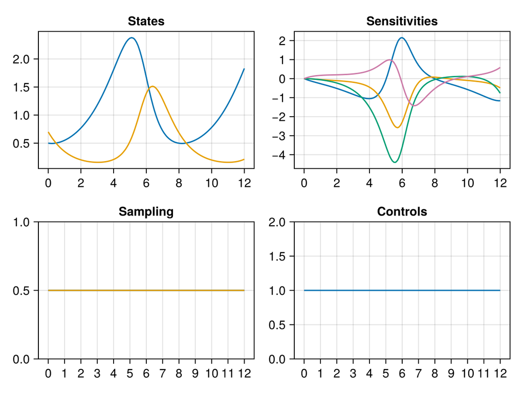

```julia
ps, st = LuxCore.setup(Random.default_rng(), oed)
sol, _ = oed(nothing, ps, st)

function plot_oed(sol)
    f = Figure()
    ax = CairoMakie.Axis(f[1, 1], xticks = 0:2:12, title = "States")
    ax2 = CairoMakie.Axis(f[1, 2], xticks = 0:2:12, title = "Sensitivities")
    ax3 = CairoMakie.Axis(f[2, 1], xticks = 0:1:12, title = "Sampling")
    ax4 = CairoMakie.Axis(f[2, 2], xticks = 0:1:12, title = "Controls")
    plot!(ax, sol, idxs = [1, 2])
    plot!(ax2, sol, idxs = [3, 4, 5, 6])
    stairs!(ax3, sol, vars = [:w₁, :w₂])
    stairs!(ax4, sol, vars = [:p₁])
    return f
end
plot_oed(sol)
```

Moreover, `CorleoneOED` provides functionalities to directly calculate the Fisher information matrix for current iterates.

```julia
fim, _ = CorleoneOED.fisher_information(oed, nothing, ps, st)
fim
```

```
2×2 Matrix{Float64}:
  8.44473  -3.37335
 -3.37335  16.5714
```

## Set up and solve the problem

With the `OEDLayer` set up, we can define the `OptimizationProblem` in one line by giving a suitable criterion to minimize, e.g., the `DCriterion`. Here, the determinant of the inverse of the Fisher information matrix is minimized. An upper bound `M` on the maximum time of measurements is specified via `M`.

```julia
optprob = OptimizationProblem(oed, DCriterion(); M = [4.0, 4.0])
uopt = solve(
    optprob, Ipopt.Optimizer(),
    tol = 1.0e-6,
    hessian_approximation = "limited-memory",
    max_iter = 300
);
```

```
This is Ipopt version 3.14.19, running with linear solver MUMPS 5.8.2.

Number of nonzeros in equality constraint Jacobian...:        0
Number of nonzeros in inequality constraint Jacobian.:      432
Number of nonzeros in Lagrangian Hessian.............:        0

Total number of variables............................:      216
                     variables with only lower bounds:        0
                variables with lower and upper bounds:      216
                     variables with only upper bounds:        0
Total number of equality constraints.................:        0
Total number of inequality constraints...............:        2
        inequality constraints with only lower bounds:        0
   inequality constraints with lower and upper bounds:        2
        inequality constraints with only upper bounds:        0

iter    objective    inf_pr   inf_du lg(mu)  ||d||  lg(rg) alpha_du alpha_pr  ls
   0  7.7891959e-03 2.00e+00 2.08e-03   0.0 0.00e+00    -  0.00e+00 0.00e+00   0
   1  1.7253260e-02 0.00e+00 4.32e-01  -1.0 1.67e-01    -  8.67e-01 1.00e+00f  1
   2  1.7075032e-02 0.00e+00 6.45e-03  -3.0 3.47e-03    -  9.85e-01 1.00e+00f  1
   3  1.2202016e-02 0.00e+00 9.86e-04  -3.3 1.38e-01    -  8.58e-01 1.00e+00f  1
   4  6.7155832e-03 0.00e+00 5.31e-04  -3.6 2.72e-01    -  9.96e-01 1.00e+00f  1
   5  3.2498179e-03 0.00e+00 3.60e-04  -4.1 3.66e-01    -  9.97e-01 1.00e+00f  1
   6  1.7912891e-03 0.00e+00 1.48e-04  -4.7 3.13e-01    -  9.97e-01 1.00e+00f  1
   7  1.0747124e-03 0.00e+00 9.14e-05  -5.4 1.86e-01    -  9.81e-01 1.00e+00f  1
   8  6.6213669e-04 0.00e+00 5.51e-05  -5.9 1.86e-01    -  9.94e-01 9.82e-01f  1
   9  4.7091358e-04 0.00e+00 2.97e-05  -6.5 3.06e-01    -  1.00e+00 9.15e-01f  1
iter    objective    inf_pr   inf_du lg(mu)  ||d||  lg(rg) alpha_du alpha_pr  ls
  10  4.2724678e-04 0.00e+00 2.95e-05  -7.0 2.72e-01    -  1.00e+00 3.74e-01f  1
  11  3.6509242e-04 0.00e+00 1.60e-05  -6.8 9.24e-01    -  1.00e+00 4.32e-01f  1
  12  5.0516392e-04 0.00e+00 2.52e-05  -5.4 1.54e+00    -  4.40e-01 3.22e-01f  1
  13  4.4473182e-04 0.00e+00 1.20e-05  -5.8 8.06e-01    -  1.00e+00 6.15e-01f  1
  14  3.5305267e-04 0.00e+00 2.51e-05  -7.0 5.55e-01    -  3.98e-01 9.79e-01f  1
  15  3.3411396e-04 0.00e+00 1.46e-05  -6.4 6.90e-01    -  9.96e-01 6.22e-01f  1
  16  3.2594940e-04 0.00e+00 1.75e-05  -7.1 2.05e-01    -  1.00e+00 2.50e-01f  1
  17  3.0192798e-04 0.00e+00 3.52e-06  -6.6 3.81e-01    -  1.00e+00 1.00e+00f  1
  18  2.9424003e-04 0.00e+00 2.91e-06  -6.8 4.49e-01    -  9.67e-01 7.86e-01f  1
  19  2.8746721e-04 0.00e+00 3.77e-06  -6.9 4.62e-01    -  9.86e-01 6.47e-01f  1
iter    objective    inf_pr   inf_du lg(mu)  ||d||  lg(rg) alpha_du alpha_pr  ls
  20  2.8040206e-04 0.00e+00 2.07e-06  -7.1 6.86e-01    -  9.98e-01 6.80e-01f  1
  21  2.7432495e-04 0.00e+00 1.04e-06  -7.2 4.69e-01    -  1.00e+00 1.00e+00f  1
  22  2.7118629e-04 0.00e+00 1.86e-06  -7.5 4.06e-01    -  9.93e-01 4.77e-01f  1
  23  2.7116270e-04 0.00e+00 5.08e-05 -11.0 7.13e-05    -  1.00e+00 1.00e+00h  1
  24  2.6934929e-04 0.00e+00 1.20e-05  -8.2 1.61e-01    -  7.99e-01 2.22e-02f  1
  25  2.6932723e-04 0.00e+00 5.70e-06 -11.0 6.11e-02    -  8.44e-01 1.19e-03f  1
  26  2.6659640e-04 0.00e+00 5.03e-06  -9.1 2.69e-01    -  1.00e+00 1.67e-01f  1
  27  2.6555769e-04 0.00e+00 3.09e-06  -8.5 4.77e-01    -  1.00e+00 1.15e-01f  1
  28  2.6455117e-04 0.00e+00 4.33e-06  -8.3 6.82e-01    -  1.00e+00 1.99e-01f  1
  29  2.6396394e-04 0.00e+00 2.71e-06  -8.5 1.17e+00    -  1.00e+00 1.49e-01f  1
iter    objective    inf_pr   inf_du lg(mu)  ||d||  lg(rg) alpha_du alpha_pr  ls
  30  2.6308559e-04 0.00e+00 2.55e-07  -8.6 4.83e-01    -  1.00e+00 3.41e-01f  1

Number of Iterations....: 30

                                   (scaled)                 (unscaled)
Objective...............:   2.6308559029860869e-04    2.6308559029860869e-04
Dual infeasibility......:   2.5475094586435807e-07    2.5475094586435807e-07
Constraint violation....:   0.0000000000000000e+00    0.0000000000000000e+00
Variable bound violation:   0.0000000000000000e+00    0.0000000000000000e+00
Complementarity.........:   1.3384505563758332e-08    1.3384505563758332e-08
Overall NLP error.......:   2.5475094586435807e-07    2.5475094586435807e-07


Number of objective function evaluations             = 31
Number of objective gradient evaluations             = 31
Number of equality constraint evaluations            = 0
Number of inequality constraint evaluations          = 31
Number of equality constraint Jacobian evaluations   = 0
Number of inequality constraint Jacobian evaluations = 31
Number of Lagrangian Hessian evaluations             = 0
Total seconds in IPOPT                               = 47.981

EXIT: Optimal Solution Found.
```

After solving, we now only need to investigate the solution.

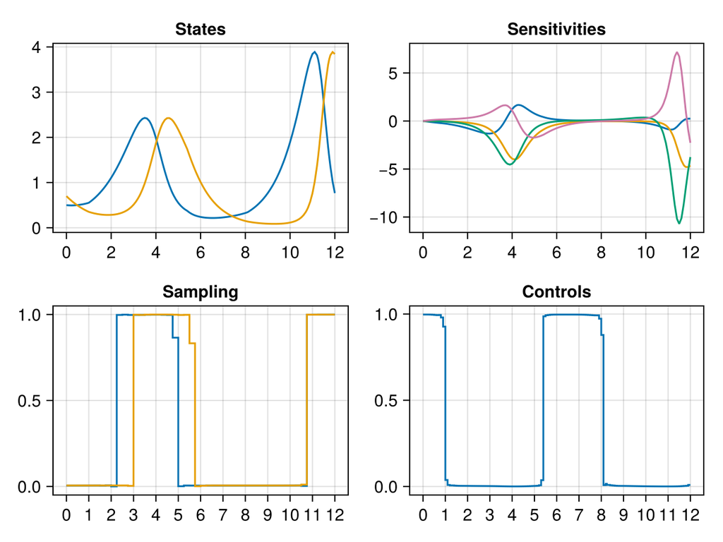

```julia
optsol, _ = oed(nothing, uopt + zero(ComponentArray(ps)), st)
plot_oed(optsol)
```

## Sampling-free OED

If the decisions about when to measure are not degrees of freedom, because, for example, continuous measurement is possible, the OEDLayer can also be constructed without discretizing the measurements. In this case, only the specified controls are degrees of freedom of the optimization.

```julia
oed = OEDLayer{false}(
    prob, Tsit5(),
    params = [2, 3],
    controls = (1 => control,),
    bounds_p = ([1.0, 1.0], [1.0, 1.0]),
    observed = (u, p, t) -> u[1:2],
)
```

[output not shown]

## Appendix

**This example was built using these direct dependencies,**

```julia
        using Pkg
        Pkg.status()
```

```
Status `~/work/Corleone.jl/Corleone.jl/docs/Project.toml`
  [13f3f980] CairoMakie v0.15.8
  [b0b7db55] ComponentArrays v0.15.32
  [2751e0db] Corleone v0.0.3 `~/work/Corleone.jl/Corleone.jl`
  [6590a4b1] CorleoneOED v0.0.2
  [e30172f5] Documenter v1.17.0
  [daee34ce] DocumenterCitations v1.4.1
  [d12716ef] DocumenterInterLinks v1.1.0
  [f6369f11] ForwardDiff v1.3.2
  [b6b21f68] Ipopt v1.14.1
  [682c06a0] JSON v1.4.0
  [98b081ad] Literate v2.21.0
  [bb33d45b] LuxCore v1.5.3
  [961ee093] ModelingToolkit v11.13.0
  [7f7a1694] Optimization v5.5.0
  [22f7324a] OptimizationLBFGSB v1.4.0
  [fd9f6733] OptimizationMOI v1.2.0
  [b1df2697] OrdinaryDiffEqTsit5 v1.9.0
  [2efcf032] SymbolicIndexingInterface v0.3.46
  [ddb6d928] YAML v0.4.16
  [9a3f8284] Random v1.11.0
```

**and using this machine and Julia version.**

```julia
        using InteractiveUtils
        InteractiveUtils.versioninfo()
```

```
Julia Version 1.12.5
Commit 5fe89b8ddc1 (2026-02-09 16:05 UTC)
Build Info:
  Official https://julialang.org release
Platform Info:
  OS: Linux (x86_64-linux-gnu)
  CPU: 4 × AMD EPYC 7763 64-Core Processor
  WORD_SIZE: 64
  LLVM: libLLVM-18.1.7 (ORCJIT, znver3)
  GC: Built with stock GC
Threads: 1 default, 1 interactive, 1 GC (on 4 virtual cores)
```

**A more complete overview of all dependencies and their versions is also provided.**

```julia
        using Pkg
        Pkg.status(; mode = PKGMODE_MANIFEST)
```

[output not shown]

[output not shown]

*This page was generated using Literate.jl.*